# Model-based Machine Learning Project

Group members

- Aryamaan Saha (s217084)
- Ananthu Sangeetha Vinod (s213605)
- Ananthalakshmi Nandakumar (s216911)

### Goal

To build a probabilistic model that can accurately predict whether a person is susceptible to heart disease, given some of his/her clinical parameters, age and gender. The dataset to be used for training our model is https://www.kaggle.com/datasets/fedesoriano/heart-failure-prediction.

### Importing necessary libaries and dataset

```python
import pandas as pd
import numpy as np
import matplotlib.pyplot as plt
import seaborn as sns

from sklearn.model_selection import train_test_split
from sklearn.preprocessing import StandardScaler
from sklearn.metrics import confusion_matrix, classification_report
from sklearn.datasets import make_classification

import torch
import pyro
import pyro.distributions as dist
from pyro.contrib.autoguide import AutoDiagonalNormal, AutoMultivariateNormal
from pyro.infer import MCMC, NUTS, HMC, SVI, Trace_ELBO
from pyro.optim import Adam, ClippedAdam
import pyro.contrib.gp as gp

sns.set()
```

```python
data = pd.read_csv('heart.csv')
data.head()
```

|  | Age | Sex | ChestPainType | RestingBP | Cholesterol | FastingBS | RestingECG | MaxHR | ExerciseAngina | Oldpeak | ST_Slope | HeartDisease |
| --- | --- | --- | --- | --- | --- | --- | --- | --- | --- | --- | --- | --- |
| 0 | 40 | M | ATA | 140 | 289 | 0 | Normal | 172 | N | 0.0 | Up | 0 |
| 1 | 49 | F | NAP | 160 | 180 | 0 | Normal | 156 | N | 1.0 | Flat | 1 |
| 2 | 37 | M | ATA | 130 | 283 | 0 | ST | 98 | N | 0.0 | Up | 0 |
| 3 | 48 | F | ASY | 138 | 214 | 0 | Normal | 108 | Y | 1.5 | Flat | 1 |
| 4 | 54 | M | NAP | 150 | 195 | 0 | Normal | 122 | N | 0.0 | Up | 0 |

# Exploratory Data Analysis

We want to first know if there are any missing values in our dataset

```python
data.isnull().sum()
```

```
Age               0
Sex               0
ChestPainType     0
RestingBP         0
Cholesterol       0
FastingBS         0
RestingECG        0
MaxHR             0
ExerciseAngina    0
Oldpeak           0
ST_Slope          0
HeartDisease      0
dtype: int64
```

Checking if there's a class imbalance in our target variable (Heart Disease)

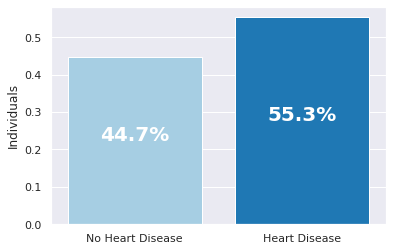

```python
dfp = pd.DataFrame(data['HeartDisease'].value_counts(normalize=True))
dfp = dfp.rename(columns={'HeartDisease':'Total_Proportion'}).reset_index()
dfp = dfp.rename(columns={'index':'HeartDisease'})

fig = plt.figure(figsize=(6, 4))
ax = sns.barplot(data=dfp, x='HeartDisease', y='Total_Proportion', \
                 palette=sns.color_palette("Paired"), saturation=1)

ax.set_xticklabels(["No Heart Disease","Heart Disease"])
ax.set_xlabel("")

ax.set_ylabel("Individuals")
for i in ax.patches:
    ax.text(x = i.get_x() + i.get_width()/2, y = i.get_height()/2,
            s = f"{i.get_height()*100:.1f}%",
            ha = 'center', size = 20, weight = 'bold', rotation = 0, color = 'white')
plt.show()
```

The percentages of each category in our target variable are very close; there is **no** class imbalance

We want to know if the percentage of heart disease is higher in a particular gender

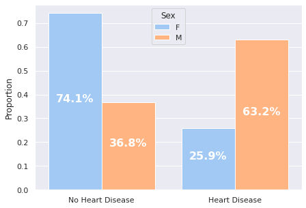

```python
df_sex = pd.DataFrame(data.groupby('Sex')['HeartDisease'].value_counts(normalize=True))
df_sex = df_sex.rename(columns={'HeartDisease':'MF_Proportion'}).reset_index(1).reset_index()

fig = plt.figure(figsize=(7, 5))
ax = sns.barplot(data=df_sex, x='HeartDisease', y='MF_Proportion', hue='Sex', \
                 palette=sns.color_palette("pastel"), saturation=1)
ax.set_xticklabels(["No Heart Disease","Heart Disease"])
ax.set_xlabel("")
ax.set_ylabel("Proportion")
# for container in ax.containers:
#     ax.bar_label(container, fmt='%.1f%%')
for i in ax.patches:
    ax.text(x = i.get_x() + i.get_width()/2, y = i.get_height()/2,
            s = f"{i.get_height()*100:.1f}%",
            ha = 'center', size = 16, weight = 'bold', rotation = 0, color = 'white')
plt.show()
```

Hmm, it seems like men are more susceptible to heart disease than women

```python
categorical_features = ['Sex', 'ChestPainType', 'FastingBS', 'RestingECG','ExerciseAngina', 'ST_Slope']
data[categorical_features] = data[categorical_features].astype(object)
```

Let us look at the correlation between the numeric features in our dataset

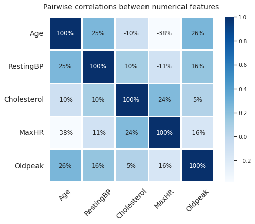

```python
fig=plt.figure(figsize=(8,6))
numerical_features = list(data.select_dtypes(['int', 'float']).columns[:-1])
ax=sns.heatmap(data[numerical_features].corr(), annot=True, linewidths=3, square=True, cmap='Blues', fmt=".0%")

ax.set_title('Pairwise correlations between numerical features', fontsize=14, x=0.50, y=1.03);
ax.set_xticklabels(numerical_features, fontsize=14, rotation = 45)
ax.set_yticklabels(numerical_features, fontsize=14, rotation= 0);
```

#### Pairplots grouped by gender

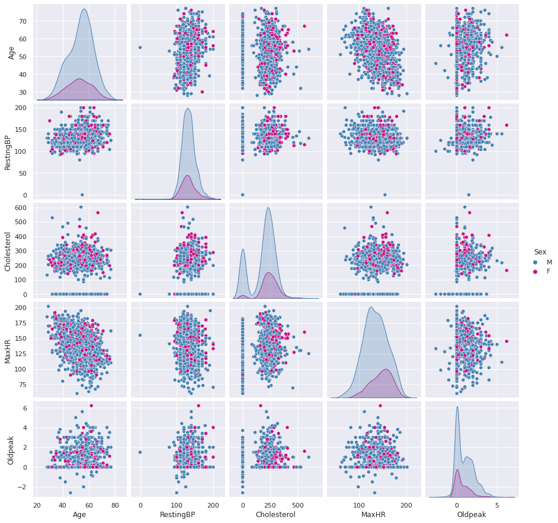

```python
sns.pairplot(data[['Sex']+numerical_features], hue='Sex', palette=['steelblue', 'mediumvioletred'])
plt.show()
```

## Modelling

First we explore a simple probabilistic binary classification model on our dataset $D$ consisting of $N$ observations of the targets $y_{n} \in$ {0, 1} which depend on their corresponding explanatory variables $x_n$

$D = ${$\textbf{x}_n, y_n$}$_{n=1}^N$

### Generative Process

1. Draw coefficients $\beta \sim \mathcal{N}(\textbf{0}, \lambda I)$
2. Draw coefficients $\alpha \sim \mathcal{N}(\textbf{0}, \tau I)$
3. For every data point n = {1,...,N}  
   a. Draw class $y_n \sim Bernoulli(Softmax(\alpha + \beta^T \textbf{x}_n))$

We convert the categorical variables into one-hot encoded columns. We also feature scale the numerical features in the dataset and concatenate it with the one-hot encoded variables, to complete the training set. We did a 75-25% train-test split.

```python
X = pd.get_dummies(data.iloc[:, :-1], drop_first=True)
y = data.iloc[:, -1]
X_train, X_test, y_train, y_test = train_test_split(X, y,  train_size=0.75, stratify = y)
scaler = StandardScaler()
X_train_num = pd.DataFrame(scaler.fit_transform(X_train[numerical_features]), columns = numerical_features)
X_test_num = pd.DataFrame(scaler.transform(X_test[numerical_features]), columns = numerical_features)
X_train_comb = pd.concat([X_train_num.reset_index(drop=True), X_train.iloc[:,5:].reset_index(drop=True)], axis=1)
X_test_comb = pd.concat([X_test_num.reset_index(drop=True), X_test.iloc[:,5:].reset_index(drop=True)], axis=1)
```

```python
trainX = torch.tensor(X_train_comb.values)
trainY = torch.tensor(y_train.values)
testX = torch.tensor(X_test_comb.values)
testY = y_test.values
```

```python
def classification_model(X, N_categories, obs=None):
    N_features = X.shape[1]
    alpha = pyro.sample("alpha", dist.Normal(torch.zeros(1, N_categories), \
                                             0.5*torch.ones(1, N_categories)).to_event())
    beta = pyro.sample("beta", dist.Normal(torch.zeros(N_features, N_categories), \
                                           0.5*torch.ones(N_features, N_categories)).to_event())

    with pyro.plate("data", X.shape[0]):
        y = pyro.sample("y", dist.Categorical(logits=alpha.double() + X.matmul(beta.double())), obs=obs)

    return y
```

```python
N_categories=2
pyro.render_model(classification_model, model_args=(trainX, N_categories, trainY))
```

[figure not shown]

### Training the model

```python
%%time
guide = AutoMultivariateNormal(classification_model)
pyro.clear_param_store()

N_steps = 40000
optimizer = ClippedAdam({"lr": 0.001})

elbo = Trace_ELBO(num_particles=1)
svi = SVI(classification_model, guide, optimizer, loss=elbo)
for step in range(N_steps):
    elbo = svi.step(trainX, N_categories, trainY)
    if step % 1000 == 0:
        print("[%d] ELBO: %.1f" % (step, elbo))
```

```
[0] ELBO: 579.9
[1000] ELBO: 277.2
[2000] ELBO: 268.5
[3000] ELBO: 266.7
[4000] ELBO: 259.2
[5000] ELBO: 263.7
[6000] ELBO: 263.6
[7000] ELBO: 262.6
[8000] ELBO: 260.1
[9000] ELBO: 260.3
[10000] ELBO: 260.0
[11000] ELBO: 260.3
[12000] ELBO: 259.4
[13000] ELBO: 260.9
[14000] ELBO: 260.8
```

[output cut: 27 more lines]

We construct a predictive distribution using the Predictive class

```python
from pyro.infer import Predictive

predictive = Predictive(classification_model, guide=guide, num_samples=2000,
                        return_sites=("alpha", "beta"))
samples = predictive(trainX, N_categories, trainY)
```

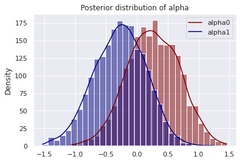

```python
samples_alpha = samples["alpha"].detach().numpy().squeeze()
for c in range(N_categories):
    sns.histplot(samples_alpha[:,c], kde=True, color= plt.get_cmap('jet_r')(float(c)))
plt.legend([f"alpha{c}" for c in range(N_categories)])
plt.ylabel('Density')
plt.title('Posterior distribution of alpha')
plt.show()
```

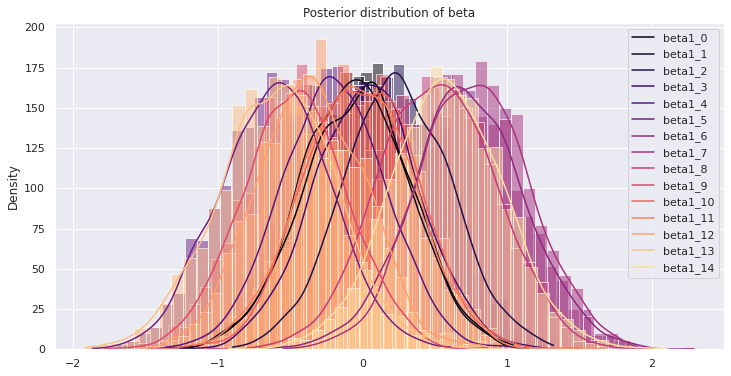

```python
for d in range(X.shape[1]):
    sns.histplot(samples["beta"].squeeze()[:,d,0].detach().numpy(), kde=True, color= plt.get_cmap('magma')(float(d)/X.shape[1]))
plt.legend([f"beta1_{d}"for d in range(X.shape[1])])
plt.gcf().set_size_inches((12,6))
plt.ylabel('Density')
plt.title('Posterior distribution of beta')
plt.show()
```

We evaluate the model on the test set using the posterior distributions of our latent variables

```python
alpha_hat = samples["alpha"].mean(axis=0).detach().numpy()
beta_hat = samples["beta"].mean(axis=0).detach().numpy()

y_hat = alpha_hat[0] + np.dot(testX, beta_hat[0])
y_hat = np.argmax(y_hat, axis=1)

print(f"Test set Accuracy: {round(100.0*np.sum(y_hat == testY) / len(testY), 3)}%")
```

```
Test set Accuracy: 87.391%
```

We can get a approximate Bayesian inference using MCMC

```python
nuts_kernel = NUTS(classification_model)
mcmc = MCMC(nuts_kernel, num_samples=500, warmup_steps=100, num_chains=1)
mcmc.run(trainX, N_categories, trainY)
```

```python
samples = mcmc.get_samples()
alpha_hat = samples["alpha"].mean(axis=0).numpy()
beta_hat = samples["beta"].mean(axis=0).numpy()
```

We can make predictions for the test set using the distributions obtained from MCMC

```python
alpha_hat = samples["alpha"].mean(axis=0).detach().numpy()
beta_hat = samples["beta"].mean(axis=0).detach().numpy()

y_hat = alpha_hat + np.dot(testX, beta_hat)
y_hat = np.argmax(y_hat, axis=1)

print(f"Test set Accuracy: {round(100.0*np.sum(y_hat == testY) / len(testY), 3)}%")
```

```
Test set Accuracy: 87.391%
```

We can plot a confusion matrix and even obtain false positive and false negative rates if required.

[figure not shown]

```python
cm = confusion_matrix(testY, y_hat)
fig, ax = plt.subplots(figsize=(5,3))
sns.heatmap(cm,annot=True,linewidths=0.5,linecolor="red",fmt=".0f",ax=ax)
plt.xlabel("True Values")
plt.ylabel("Predicted Values")
plt.title('Confusion Matrix')
plt.show()
```

```python
print(classification_report(testY, y_hat))
```

```
              precision    recall  f1-score   support

           0       0.86      0.86      0.86       103
           1       0.89      0.88      0.89       127

    accuracy                           0.87       230
   macro avg       0.87      0.87      0.87       230
weighted avg       0.87      0.87      0.87       230
```

## Hierarchical Model by Gender

In the exploratory data analysis, we discovered that men are more susceptible to heart disease than women, according to our data. A simple binary classification model assumes that all individuals have identical biases and give same importance to all features, and a single set of parameters is used for all the observations. We can instead explore a hierarchical model, which divides the individuals into two groups based on gender. The data from each group gets its own set of parameters and a shared global prior ties together the parameters for each group.

## Part 1 - Priors on the bias

We can design a hierarchical model in many ways. We first set a hierarchical prior on the intercepts (biases) and defined our model according to the following generative process.

### Generative Process

1. Draw global mean parameter $\mu_{\alpha} \sim \mathcal{N}(0, 10)$
2. Draw global variance parameter $\sigma_{\alpha} \sim \mathcal{HalfCauchy}(0, 10)$
3. Draw coefficients $\boldsymbol\beta$ $\sim \mathcal{N}(\textbf{0}, 10\mathbf{I})$
4. For each group(gender) g $\in$ {M, F}  
   a. Draw coefficients $\alpha^{g} \sim \mathcal{N}(\mu_{\alpha}, \sigma_{\alpha})$
5. For each data point n = {1, ..., N}  
   a. Draw class $y_n \sim Bernoulli(Softmax( \textbf{x}_n, \alpha^{g}, \boldsymbol\beta))$

```python
X = pd.get_dummies(data.iloc[:, :-1], drop_first=True)
y = data.iloc[:, -1]
X_train, X_test, y_train, y_test = train_test_split(X, y,  train_size=0.75, stratify = y)
scaler = StandardScaler()
X_train_num = pd.DataFrame(scaler.fit_transform(X_train[numerical_features]), columns = numerical_features)
X_test_num = pd.DataFrame(scaler.transform(X_test[numerical_features]), columns = numerical_features)
X_train_comb = pd.concat([X_train_num.reset_index(drop=True), X_train.iloc[:,5:].reset_index(drop=True)], axis=1)
X_test_comb = pd.concat([X_test_num.reset_index(drop=True), X_test.iloc[:,5:].reset_index(drop=True)], axis=1)
gender_ind_train = X_train_comb['Sex_M']
gender_ind_test = X_test_comb['Sex_M']
gender_ind_train = torch.tensor(gender_ind_train).long()
gender_ind_test = torch.tensor(gender_ind_test).long()
X_train_sex = X_train_comb.drop(['Sex_M'], axis=1)
X_test_sex = X_test_comb.drop(['Sex_M'], axis=1)
```

```python
trainX = torch.tensor(X_train_sex.values)
trainY = torch.tensor(y_train.values)
testX = torch.tensor(X_test_sex.values)
testY = y_test.values
```

```python
def hierarchical_gender_model_0(X, N_categories, N_genders, gender_ind, obs=None):
    N_features = X.shape[1]
    alpha_mu = pyro.sample("alpha_mu", dist.Normal(torch.zeros(N_categories), \
                                                   10.*torch.ones(N_categories)).to_event())
    alpha_sigma  = pyro.sample("alpha_sigma",  dist.HalfCauchy(10.*torch.ones(N_categories)).to_event())
    beta  = pyro.sample("beta", dist.Normal(torch.zeros(N_features, N_categories), \
                                            10.*torch.ones(N_features, N_categories)).to_event())

    with pyro.plate("genders", N_genders):
        alpha = pyro.sample("alpha", dist.Normal(alpha_mu, alpha_sigma).to_event(1))
    with pyro.plate("data", X.shape[0]):
        logits = alpha[gender_ind].double() + X.matmul(beta.double())
        y = pyro.sample("y", dist.Categorical(logits=logits), obs=obs)

    return y
```

```python
N_categories = 2
N_genders = 2
pyro.render_model(hierarchical_gender_model_0, model_args=(trainX, N_categories, N_genders, \
                                                           gender_ind_train, trainY))
```

[figure not shown]

```python
%%time
guide = AutoDiagonalNormal(hierarchical_gender_model_0)
pyro.clear_param_store()

N_steps = 25000
optimizer = ClippedAdam({"lr": 0.01})

elbo = Trace_ELBO(num_particles=3)
svi = SVI(hierarchical_gender_model_0, guide, optimizer, loss=elbo)
for step in range(N_steps):
    elbo = svi.step(trainX, N_categories, N_genders, gender_ind_train, trainY)
    if step % 500 == 0:
        print("[%d] ELBO: %.1f" % (step, elbo))
```

```
[0] ELBO: 7226.1
[500] ELBO: 458.3
[1000] ELBO: 350.1
[1500] ELBO: 352.8
[2000] ELBO: 354.2
[2500] ELBO: 350.0
[3000] ELBO: 340.9
[3500] ELBO: 345.5
[4000] ELBO: 343.4
[4500] ELBO: 349.8
[5000] ELBO: 350.9
[5500] ELBO: 354.0
[6000] ELBO: 346.2
[6500] ELBO: 355.6
[7000] ELBO: 344.5
```

[output cut: 37 more lines]

```python
predictive = Predictive(hierarchical_gender_model_0, guide=guide, num_samples=2000,
                        return_sites=("beta", "alpha", "alpha_mu", "alpha_sigma"))
samples = predictive(trainX, N_categories, N_genders, gender_ind_train, trainY)
beta_samples = samples["beta"].detach().numpy()
alpha_samples = samples["alpha"].detach().numpy()
alpha_mu_samples = samples["alpha_mu"].detach().numpy()
alpha_sigma_samples = samples["alpha_sigma"].detach().numpy()
alpha_hat = samples["alpha"].mean(axis=0).detach().numpy()
beta_hat = samples["beta"][:,0].mean(axis=0).detach().numpy()
```

```python
y_hat = alpha_hat[gender_ind_test] + np.dot(testX, beta_hat)
y_hat = np.argmax(y_hat, axis=1)

print(f"Test set Accuracy: {round(100.0*np.sum(y_hat == testY) / len(testY), 3)}%")
```

```
Test set Accuracy: 86.522%
```

[figure not shown]

```
              precision    recall  f1-score   support

           0       0.90      0.79      0.84       103
           1       0.84      0.93      0.88       127

    accuracy                           0.87       230
   macro avg       0.87      0.86      0.86       230
weighted avg       0.87      0.87      0.86       230
```

```python
cm = confusion_matrix(testY, y_hat)
fig, ax = plt.subplots(figsize=(5,3))
sns.heatmap(cm,annot=True,linewidths=0.5,linecolor="red",fmt=".0f",ax=ax)
plt.xlabel("True Values")
plt.ylabel("Predicted Values")
plt.title('Confusion Matrix')
plt.show()
print(classification_report(testY, y_hat))
```

The test set accuracy hasn't improved from the simple bayesian logistic regression model that we trained earlier. Let's see if we can improve this hierarchical model.

## Part 2 - Priors on the bias and weights

### Generative Process

1. Draw global mean parameter for bias $\mu_{\alpha} \sim \mathcal{N}(0, 10)$
2. Draw global variance parameter for bias $\sigma_{\alpha} \sim \mathcal{HalfCauchy}(0, 10)$
3. Draw global mean parameter for weights $\mu_{\beta} \sim \mathcal{N}(0, 10)$
4. Draw global variance parameter for weights $\sigma_{\beta} \sim \mathcal{HalfCauchy}(0, 10)$
5. For each group(gender) g $\in$ {M, F}  
   a. Draw coefficients $\alpha^{g} \sim \mathcal{N}(\mu_{\alpha}, \sigma_{\alpha})$  
   b. Draw coefficients $\boldsymbol \beta^{g} \sim \mathcal{N}(\mu_{\beta}, \sigma_{\beta})$
6. For each data point n = {1, ..., N}  
   a. Draw class $y_n \sim Bernoulli(Softmax( \textbf{x}_n, \alpha^{g}, \boldsymbol\beta^{g}))$

```python
def hierarchical_gender_model(X, N_categories, N_genders, gender_ind, obs=None):
    N_features = X.shape[1]
    alpha_mu = pyro.sample("alpha_mu", dist.Normal(torch.zeros(N_categories), \
                                                   10.*torch.ones(N_categories)).to_event())
    alpha_sigma  = pyro.sample("alpha_sigma",  dist.HalfCauchy(10.*torch.ones(N_categories)).to_event())
    beta_mu = pyro.sample("beta_mu", dist.Normal(torch.zeros(N_features, N_categories), \
                                                 10.*torch.ones(N_features, N_categories)).to_event())
    beta_sigma  = pyro.sample("beta_sigma",  dist.HalfCauchy(10.*torch.ones(N_features, N_categories)).to_event())
    with pyro.plate("genders", N_genders):
        alpha = pyro.sample("alpha", dist.Normal(alpha_mu, alpha_sigma).to_event(1))
        beta = pyro.sample("beta", dist.Normal(beta_mu, beta_sigma).to_event(2))
    with pyro.plate("data", X.shape[0]):
        logits = alpha[gender_ind].double() \
                + torch.stack([X[i].matmul(beta[gender_ind][i].double()) for i in range(X.shape[0])])
        y = pyro.sample("y", dist.Categorical(logits=logits), obs=obs)

    return y
```

```python
N_categories = 2
N_genders = 2
pyro.render_model(hierarchical_gender_model, model_args=(trainX, N_categories, \
                                                         N_genders, gender_ind_train, trainY))
```

[figure not shown]

```python
%%time
guide = AutoDiagonalNormal(hierarchical_gender_model)
pyro.clear_param_store()

N_steps = 12500
optimizer = ClippedAdam({"lr": 0.01})

elbo = Trace_ELBO(num_particles=3)
svi = SVI(hierarchical_gender_model, guide, optimizer, loss=elbo)
for step in range(N_steps):
    elbo = svi.step(trainX, N_categories, N_genders, gender_ind_train, trainY)
    if step % 500 == 0:
        print("[%d] ELBO: %.1f" % (step, elbo))
```

```
[0] ELBO: 3577.2
[500] ELBO: 537.5
[1000] ELBO: 456.3
[1500] ELBO: 440.7
[2000] ELBO: 427.1
[2500] ELBO: 433.9
[3000] ELBO: 430.3
[3500] ELBO: 426.6
[4000] ELBO: 452.4
[4500] ELBO: 442.4
[5000] ELBO: 429.7
[5500] ELBO: 430.4
[6000] ELBO: 433.1
[6500] ELBO: 422.5
[7000] ELBO: 429.6
[7500] ELBO: 429.5
[8000] ELBO: 432.0
[8500] ELBO: 421.1
[9000] ELBO: 422.2
[9500] ELBO: 426.1
[10000] ELBO: 429.0
[10500] ELBO: 427.3
[11000] ELBO: 415.7
[11500] ELBO: 418.9
[12000] ELBO: 428.4
CPU times: user 2h 49min 51s, sys: 2min 12s, total: 2h 52min 3s
Wall time: 43min 6s
```

As earlier, we can use the Predictive class to obtain the posterior distributions.

```python
predictive = Predictive(hierarchical_gender_model, guide=guide, num_samples=2000, \
                        return_sites=("beta", "alpha"))
samples = predictive(trainX, N_categories, N_genders, gender_ind_train, trainY)
```

```python
beta_samples = samples["beta"].detach().numpy()
alpha_samples = samples["alpha"].detach().numpy()
alpha_hat = samples["alpha"].mean(axis=0).detach().numpy()
beta_hat = samples["beta"][:].mean(axis=0).detach().numpy()
```

```python
y_hat = alpha_hat[gender_ind_test,:] \
        + torch.stack([testX[i].matmul(torch.tensor(beta_hat[gender_ind_test][i]).double()) for i in range(
                                                                            testX.shape[0])]).detach().numpy()
y_hat = np.argmax(y_hat, axis=1)

print(f"Test set Accuracy: {round(100.0*np.sum(y_hat == testY) / len(testY), 3)}%")
```

```
Test set Accuracy: 83.043%
```

The test set accuracy has not improved despite adding a global prior to the $\beta$ coefficients. In fact, we observe that the model has taken much longer to train as well, and accuracy is slightly worse off than before. This is likely due to the additional complexity, which could have led to overfitting.

Note: Since it takes so long to train, we have minimized the epochs. When we ran the model for more epochs it gave a better accuracy, increasing to about 85-86%.

## Hierarchical Model by Age

Another way we could explore grouping of individuals is via age of the individuals. If the susceptibility towards heart disease is significantly different between age groups, then we could assign distinct biases to those groups while designing the model. First we could need to explore if there is indeed a difference in susceptibility.

```
Mean: 53.510893246187365, Standard Deviation: 9.432616506732007
```

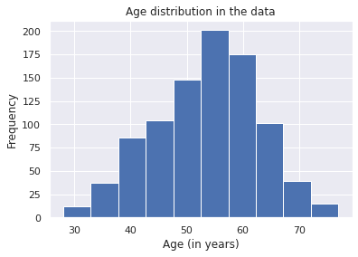

```python
age_mean = data['Age'].mean()
age_std = data['Age'].std()
print(f'Mean: {age_mean}, Standard Deviation: {age_std}')
data['Age'].plot(kind='hist')
plt.title('Age distribution in the data')
plt.xlabel('Age (in years)')
plt.show()
```

We decided to split the observations into 3 groups based on the distribution of age in the data.  
a. Individuals with age < $\mu - 0.5\sigma$ (denoted by 0)  
b. Individuals with $\mu - 0.5\sigma$ $\le$ age $\le$ $\mu + 0.5\sigma$ (denoted by 1)  
c. Individuals with age > $\mu + 0.5\sigma$ (denoted by 2)

```python
def age_to_level(age):
    if age <= age_mean+0.5*age_std and age >= age_mean-0.5*age_std:
        return 1
    elif age < age_mean-0.5*age_std:
        return 0
    elif age > age_mean+0.5*age_std:
        return 2
```

```python
data2 = data.copy()
data2.insert(loc=2, column='Age Level', value='')
data2['Age Level'] = data2['Age'].apply(age_to_level)
data2['Age Level'].value_counts()
```

```
1    360
2    288
0    270
Name: Age Level, dtype: int64
```

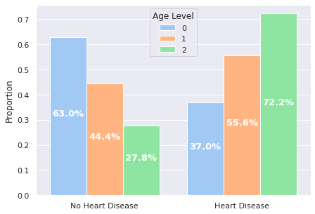

```python
df_age = pd.DataFrame(data2.groupby('Age Level')['HeartDisease'].value_counts(normalize=True))
df_age = df_age.rename(columns={'HeartDisease':'AL_Proportion'}).reset_index(1).reset_index()

fig = plt.figure(figsize=(7, 5))
ax = sns.barplot(data=df_age, x='HeartDisease', y='AL_Proportion', hue='Age Level', palette=sns.color_palette("pastel"), saturation=1)
ax.set_xticklabels(["No Heart Disease","Heart Disease"])
ax.set_xlabel("")
ax.set_ylabel("Proportion")

for i in ax.patches:
    ax.text(x = i.get_x() + i.get_width()/2, y = i.get_height()/2,
            s = f"{i.get_height()*100:.1f}%",
            ha = 'center', size = 13, weight = 'bold', rotation = 0, color = 'white')
plt.show()
```

As expected, young people are less likely to get heart disease and the susceptibility is to heart disease is more in higher age groups. We can commence with our hierarchical model using these 3 age groups. We just define priors on the biases (intercepts) and not on the $\beta$ coefficients.

### Generative Process

1. Draw global mean parameter $\mu_{\alpha} \sim \mathcal{N}(0, 10)$
2. Draw global variance parameter $\sigma_{\alpha} \sim \mathcal{HalfCauchy}(0, 10)$
3. Draw coefficients $\boldsymbol\beta$ $\sim \mathcal{N}(\textbf{0}, 10\mathbf{I})$
4. For each group(age level) a $\in$ {0, 1, 2}  
   a. Draw coefficients $\alpha^{a} \sim \mathcal{N}(\mu_{\alpha}, \sigma_{\alpha})$
5. For each data point n = {1, ..., N}  
   a. Draw class $y_n \sim Bernoulli(Softmax( \textbf{x}_n, \alpha^{a}, \boldsymbol\beta))$

```python
X = pd.get_dummies(data2.iloc[:, 1:-1], drop_first=True)
y = data2.iloc[:, -1]
X_train, X_test, y_train, y_test = train_test_split(X, y,  train_size=0.75, stratify = y)
age_ind_train = X_train['Age Level']
age_ind_test = X_test['Age Level']
age_ind_train = torch.tensor(age_ind_train.values, dtype=torch.int64).long()
age_ind_test = torch.tensor(age_ind_test.values, dtype=torch.int64).long()
X_train=X_train.drop("Age Level", axis=1)
X_test=X_test.drop("Age Level", axis=1)
numerical_features_wo_age = numerical_features[1:]
X_train_num = pd.DataFrame(scaler.fit_transform(X_train[numerical_features_wo_age]), columns = numerical_features_wo_age)
X_test_num = pd.DataFrame(scaler.transform(X_test[numerical_features_wo_age]), columns = numerical_features_wo_age)
X_train_age = pd.concat([X_train_num.reset_index(drop=True), X_train.loc[:, ['Sex_M']].reset_index(drop=True), X_train.iloc[:,5:].reset_index(drop=True)], axis=1)
X_test_age = pd.concat([X_test_num.reset_index(drop=True), X_test.loc[:, ['Sex_M']].reset_index(drop=True), X_test.iloc[:,5:].reset_index(drop=True)], axis=1)
```

```python
trainX = torch.tensor(X_train_age.values)
trainY = torch.tensor(y_train.values)
testX = torch.tensor(X_test_age.values)
testY = y_test.values
```

```python
def hierarchical_age_model(X, N_categories, N_agegroups, age_ind, obs=None):
    N_features = X.shape[1]
    alpha_mu = pyro.sample("alpha_mu", dist.Normal(torch.zeros(N_categories), 10.*torch.ones(N_categories)).to_event())
    alpha_sigma  = pyro.sample("alpha_sigma",  dist.HalfCauchy(10.*torch.ones(N_categories)).to_event())
    beta  = pyro.sample("beta", dist.Normal(torch.zeros(N_features, N_categories), 10.*torch.ones(N_features, N_categories)).to_event())

    with pyro.plate("age groups", N_agegroups):
        alpha = pyro.sample("alpha", dist.Normal(alpha_mu, alpha_sigma).to_event(1))
    with pyro.plate("data", X.shape[0]):
        logits = alpha[age_ind].double() + X.matmul(beta.double())
        y = pyro.sample("y", dist.Categorical(logits=logits), obs=obs)

    return y
```

```python
N_categories = 2
N_agegroups = 3
pyro.render_model(hierarchical_age_model, model_args=(trainX, N_categories, N_agegroups, age_ind_train, trainY))
```

[figure not shown]

```python
%%time
guide = AutoDiagonalNormal(hierarchical_age_model)
pyro.clear_param_store()

N_steps = 20000
optimizer = ClippedAdam({"lr": 0.007})

elbo = Trace_ELBO(num_particles=3)
svi = SVI(hierarchical_age_model, guide, optimizer, loss=elbo)
for step in range(N_steps):
    elbo = svi.step(trainX, N_categories, N_agegroups, age_ind_train, trainY)
    if step % 500 == 0:
        print("[%d] ELBO: %.1f" % (step, elbo))
```

```
[0] ELBO: 6180.8
[500] ELBO: 706.9
[1000] ELBO: 386.4
[1500] ELBO: 386.5
[2000] ELBO: 365.0
[2500] ELBO: 354.2
[3000] ELBO: 365.6
[3500] ELBO: 360.2
[4000] ELBO: 358.3
[4500] ELBO: 363.8
[5000] ELBO: 362.8
[5500] ELBO: 371.6
[6000] ELBO: 359.2
[6500] ELBO: 359.7
[7000] ELBO: 361.1
```

[output cut: 27 more lines]

```python
predictive = Predictive(hierarchical_age_model, guide=guide, num_samples=2000, \
                        return_sites=("beta", "alpha", "alpha_mu", "alpha_sigma"))
samples = predictive(trainX, N_categories, N_agegroups, age_ind_train, trainY)
beta_samples = samples["beta"].detach().numpy()
alpha_samples = samples["alpha"].detach().numpy()
alpha_hat = samples["alpha"].mean(axis=0).detach().numpy()
beta_hat = samples["beta"][:,0].mean(axis=0).detach().numpy()
```

```python
y_hat = alpha_hat[age_ind_test] + np.dot(testX, beta_hat)
y_hat = np.argmax(y_hat, axis=1)

print(f"Test set Accuracy: {round(100.0*np.sum(y_hat == testY) / len(testY), 3)}%")
```

```
Test set Accuracy: 87.391%
```

[figure not shown]

```
              precision    recall  f1-score   support

           0       0.85      0.87      0.86       103
           1       0.90      0.87      0.88       127

    accuracy                           0.87       230
   macro avg       0.87      0.87      0.87       230
weighted avg       0.87      0.87      0.87       230
```

```python
cm = confusion_matrix(testY, y_hat)
fig, ax = plt.subplots(figsize=(5,3))
sns.heatmap(cm,annot=True,linewidths=0.5,linecolor="red",fmt=".0f",ax=ax)
plt.xlabel("True Values")
plt.ylabel("Predicted Values")
plt.title('Confusion Matrix')
plt.show()
print(classification_report(testY, y_hat))
```

# Hierarchical Model by Age and Gender

We can combine the two hierarchical models above to design a hierarchy based on two levels - gender and age. We do this by assigning a bias $\gamma$ seperately encoding the bias for age groups, along with $\alpha$ encoding the bias for different genders. We state the global priors that tie together the parameters for each level seperately for gender and age groups.

### Generative Process

1. Draw global mean parameter for gender bias $\mu_{\alpha} \sim \mathcal{N}(0, 10)$
2. Draw global variance parameter for gender bias $\sigma_{\alpha} \sim \mathcal{HalfCauchy}(0, 10)$
3. Draw global mean parameter for age bias $\mu_{\gamma} \sim \mathcal{N}(0, 10)$
4. Draw global variance parameter for age bias $\sigma_{\gamma} \sim \mathcal{HalfCauchy}(0, 10)$
5. Draw coefficients $\boldsymbol\beta$ $\sim \mathcal{N}(\textbf{0}, 10\mathbf{I})$
6. For each group(gender) g $\in$ {M, F}  
   a. Draw coefficients $\alpha^{g} \sim \mathcal{N}(\mu_{\alpha}, \sigma_{\alpha})$
7. For each group(age level) a $\in$ {0, 1, 2}  
   a. Draw coefficients $\gamma^{a} \sim \mathcal{N}(\mu_{\gamma}, \sigma_{\gamma})$
8. For each data point n = {1, ..., N}  
   a. Draw class $y_n \sim Bernoulli(Softmax( \textbf{x}_n, \alpha^{g}, \gamma^{a}, \boldsymbol\beta))$

```python
gender_ind_train = X_train_age['Sex_M']
gender_ind_test = X_test_age['Sex_M']
gender_ind_train = torch.tensor(gender_ind_train).long()
gender_ind_test = torch.tensor(gender_ind_test).long()
X_train_both = X_train_age.drop(['Sex_M'], axis=1)
X_test_both = X_test_age.drop(['Sex_M'], axis=1)
```

```python
trainX = torch.tensor(X_train_both.values)
trainY = torch.tensor(y_train.values)
testX = torch.tensor(X_test_both.values)
testY = y_test.values
```

```python
def hierarchical_gender_age_model(X, N_categories, N_genders, N_agegroups, age_ind, gender_ind, obs=None):
    N_features = X.shape[1]
    alpha_mu = pyro.sample("alpha_mu", dist.Normal(torch.zeros(N_categories), \
                                                   10.*torch.ones(N_categories)).to_event())
    alpha_sigma  = pyro.sample("alpha_sigma",  dist.HalfCauchy(10.*torch.ones(N_categories)).to_event())
    beta  = pyro.sample("beta", dist.Normal(torch.zeros(N_features, N_categories), \
                                            10.*torch.ones(N_features, N_categories)).to_event())
    with pyro.plate("genders", N_genders):
        alpha = pyro.sample("alpha", dist.Normal(alpha_mu, alpha_sigma).to_event(1))

    gamma_mu = pyro.sample("gamma_mu", dist.Normal(torch.zeros(N_categories), \
                                                   10.*torch.ones(N_categories)).to_event())
    gamma_sigma  = pyro.sample("gamma_sigma",  dist.HalfCauchy(10.*torch.ones(N_categories)).to_event())

    with pyro.plate("age levels", N_agegroups):
        gamma = pyro.sample("gamma", dist.Normal(gamma_mu, gamma_sigma).to_event(1))

    with pyro.plate("data", X.shape[0]):
        logits = gamma[age_ind].double() + alpha[gender_ind].double() + X.matmul(beta.double())
        y = pyro.sample("y", dist.Categorical(logits=logits), obs=obs)

    return y
```

```python
N_categories = 2
N_agegroups = 3
N_genders = 2
pyro.render_model(hierarchical_gender_age_model, model_args=(trainX, N_categories, N_genders, \
                                         N_agegroups, age_ind_train, gender_ind_train, trainY))
```

[figure not shown]

```python
%%time
guide = AutoDiagonalNormal(hierarchical_gender_age_model)
pyro.clear_param_store()

N_steps = 25000
optimizer = ClippedAdam({"lr": 0.007})

elbo = Trace_ELBO(num_particles=3)
svi = SVI(hierarchical_gender_age_model, guide, optimizer, loss=elbo)
for step in range(N_steps):
    elbo = svi.step(trainX, N_categories, N_genders, \
                    N_agegroups, age_ind_train, gender_ind_train, trainY)
    if step % 500 == 0:
        print("[%d] ELBO: %.1f" % (step, elbo))
```

```
[0] ELBO: 4798.8
[500] ELBO: 739.5
[1000] ELBO: 412.9
[1500] ELBO: 385.7
[2000] ELBO: 369.7
[2500] ELBO: 372.2
[3000] ELBO: 375.8
[3500] ELBO: 362.8
[4000] ELBO: 366.6
[4500] ELBO: 365.8
[5000] ELBO: 371.5
[5500] ELBO: 372.0
[6000] ELBO: 374.2
[6500] ELBO: 365.5
[7000] ELBO: 370.2
```

[output cut: 37 more lines]

```python
predictive = Predictive(hierarchical_gender_age_model, guide=guide, num_samples=2000, \
                        return_sites=("beta", "alpha", "gamma"))
samples = predictive(trainX, N_categories, N_genders, \
                    N_agegroups, age_ind_train, gender_ind_train, trainY)
beta_samples = samples["beta"].detach().numpy()
alpha_samples = samples["alpha"].detach().numpy()
gamma_samples = samples["gamma"].detach().numpy()
alpha_hat = samples["alpha"].mean(axis=0).detach().numpy()
gamma_hat = samples["gamma"].mean(axis=0).detach().numpy()
beta_hat = samples["beta"][:,0].mean(axis=0).detach().numpy()
```

```python
y_hat = gamma_hat[age_ind_test] + alpha_hat[gender_ind_test] + np.dot(testX, beta_hat)
y_hat = np.argmax(y_hat, axis=1)

print(f"Test set Accuracy: {round(100.0*np.sum(y_hat == testY) / len(testY), 3)}%")
```

```
Test set Accuracy: 86.957%
```

[figure not shown]

```
              precision    recall  f1-score   support

           0       0.86      0.84      0.85       103
           1       0.88      0.89      0.88       127

    accuracy                           0.87       230
   macro avg       0.87      0.87      0.87       230
weighted avg       0.87      0.87      0.87       230
```

```python
cm = confusion_matrix(testY, y_hat)
fig, ax = plt.subplots(figsize=(5,3))
sns.heatmap(cm,annot=True,linewidths=0.5,linecolor="red",fmt=".0f",ax=ax)
plt.xlabel("True Values")
plt.ylabel("Predicted Values")
plt.title('Confusion Matrix')
plt.show()
print(classification_report(testY, y_hat))
```

We explored many bayesian classification models from logistic regression to hierarchical models based on age and gender, and we observed that the accuracy didn't significantly change across models. Let's explore gaussian process classification now, and see if there's an improvement in the accuracy.

## Classification using Gaussian Processes

The model we’re interested in is defined by $\textbf{f}$ ~ $\textit{GP}$($\textbf{0}$,$K_f$($\textit(x,x')$) \& $\textbf{y = f(x) }$+ $\epsilon$

```python
X = pd.get_dummies(data.iloc[:, :-1], drop_first=True)
y = data.iloc[:, -1]
X,y = make_classification(n_samples=X.shape[0], n_features=X.shape[1],n_redundant=0,
                          n_repeated=0,n_clusters_per_class = 2, n_classes=2,random_state=30)
train_size = int(0.75*X.shape[0])
X_train = X[:train_size,:]
y_train =y[:train_size]
X_test = X[train_size:,:]
y_test =y[train_size:]
X_train = torch.tensor(X_train,dtype= torch.float32)
y_train = torch.tensor(y_train, dtype=torch.float32)
X_test = torch.tensor(X_test,dtype= torch.float32)
y_test = torch.tensor(y_test, dtype=torch.float32)
```

### Training the model

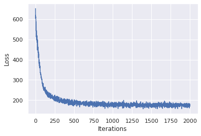

```python
kernel = gp.kernels.RBF(input_dim=15)
pyro.clear_param_store()
likelihood = gp.likelihoods.MultiClass(num_classes=2)
GP_model = gp.models.VariationalGP(
    X_train,
    y_train,
    kernel,
    likelihood=likelihood,
    whiten=True,
    jitter=1e-03,
    latent_shape=torch.Size([2]),
)
num_steps = 2000
loss = gp.util.train(GP_model, num_steps=num_steps)
plt.plot(loss)
plt.xlabel("Iterations")
plt.ylabel("Loss")
plt.show()
```

### Evaluating the model on test set

```python
mean, var = GP_model(X_test)
y_hat = GP_model.likelihood(mean, var)
print(f"Accuracy: {100.0*(y_test==y_hat).sum()/len(y_test):.3f}%")
```

```
Accuracy: 92.174%
```

[figure not shown]

```
              precision    recall  f1-score   support

         0.0       0.90      0.94      0.92       109
         1.0       0.94      0.91      0.92       121

    accuracy                           0.92       230
   macro avg       0.92      0.92      0.92       230
weighted avg       0.92      0.92      0.92       230
```

```python
cm = confusion_matrix(y_test.detach().numpy(), y_hat.detach().numpy())
fig, ax = plt.subplots(figsize=(5,3))
sns.heatmap(cm,annot=True,linewidths=0.5,linecolor="red",fmt=".0f",ax=ax)
plt.xlabel("True Values")
plt.ylabel("Predicted Values")
plt.title('Confusion Matrix')
plt.show()
print(classification_report(y_test.detach().numpy(), y_hat.detach().numpy()))
```

# Conclusion

Multiple training attempts and models later, we find that the test set accuracy for the bayesian logistic regression models and the hierarchical logistic regression models generally hover around 85-87% and do not improve significantly even after adding more levels, and training for longer. It's likely that the distinction between groups in the hierarchical models are not significant enough over large amount of data, to be an improvement over the plain bayesian logistic regression model. Placing identical biases and weights to all observations works equally well as not doing so (hierarchies).